# Exploratory Data Analysis

## Project Data

Let’s start with exploratory data analysis of the project-specific data. This includes information on school location, school type, teacher attributes, project categories, project pricing and impact, project donations, and project status.

#### Importing the file

```r
project_orig <- read.csv(gzfile("opendata_projects000.gz"), sep = ",", header = FALSE, col.names = c('_projectid', '_teacher_acctid', '_schoolid', 'school_ncesid', 'school_latitude', 'school_longitude', 'school_city', 'school_state', 'school_zip', 'school_metro', 'school_district', 'school_county', 'school_charter', 'school_magnet', 'school_year_round', 'school_nlns', 'school_kipp', 'school_charter_ready_promise', 'teacher_prefix', 'teacher_teach_for_america', 'teacher_ny_teaching_fellow', 'primary_focus_subject', 'primary_focus_area' ,'secondary_focus_subject', 'secondary_focus_area', 'resource_type', 'poverty_level', 'grade_level', 'vendor_shipping_charges', 'sales_tax', 'payment_processing_charges', 'fulfillment_labor_materials', 'total_price_excluding_optional_support', 'total_price_including_optional_support', 'students_reached', 'total_donations', 'num_donors', 'eligible_double_your_impact_match', 'eligible_almost_home_match', 'funding_status', 'date_posted', 'date_completed', 'date_thank_you_packet_mailed', 'date_expiration'))
```

#### Cleaning the data

```r
project <- tbl_df(project_orig)
project$X_projectid <- as.character(project$X_projectid)
project$X_teacher_acctid <- as.character(project$X_teacher_acctid)
project$X_schoolid <- as.character(project$X_schoolid)
project$school_ncesid <- as.character(project$school_ncesid)

project$school_zip <- as.factor(project$school_zip)

project$school_charter <- as.logical(toupper(as.character(project$school_charter)))
project$school_magnet <- as.logical(toupper(as.character(project$school_magnet)))
project$school_year_round <- as.logical(toupper(as.character(project$school_year_round)))
project$school_nlns <- as.logical(toupper(as.character(project$school_nlns)))
project$school_kipp <- as.logical(toupper(as.character(project$school_kipp)))
project$school_charter_ready_promise <- as.logical(toupper(as.character(project$school_charter_ready_promise)))
project$teacher_teach_for_america <- as.logical(toupper(as.character(project$teacher_teach_for_america)))
project$teacher_ny_teaching_fellow <- as.logical(toupper(as.character(project$teacher_ny_teaching_fellow)))
project$eligible_double_your_impact_match <- as.logical(toupper(as.character(project$eligible_double_your_impact_match)))
project$eligible_almost_home_match <- as.logical(toupper(as.character(project$eligible_almost_home_match)))

project$date_posted <- as.Date(project$date_posted)
project$date_completed <- as.Date(project$date_completed)
project$date_thank_you_packet_mailed <- as.Date(project$date_thank_you_packet_mailed)
project$date_expiration <- as.Date(project$date_expiration)

project$grade_level <- factor(project$grade_level, levels = c("", "Grades PreK-2", "Grades 3-5", "Grades 6-8", "Grades 9-12"))
project$poverty_level <- factor(project$poverty_level, levels = c("", "low poverty", "moderate poverty", "high poverty", "highest poverty"))
```

#### Funding status

Since the goal of this capstone project is to predict whether or not a project will be successfully funded, let’s first take a look at the different options for funding status.

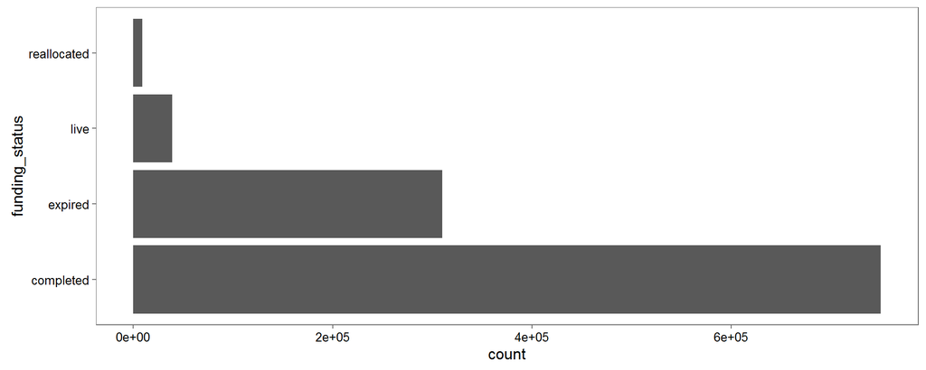

```r
ggplot(project, aes(x = funding_status)) + geom_bar() + coord_flip() + theme_few()
```

We will only focus on the projects that are either completed (successfully funded) or expired (did not reach funding goal), and remove the live and reallocated projects.

```r
project <- project %>% filter(funding_status == "completed" | funding_status == "expired")
```

Next, let’s look at some of the properties of each project (type of school, type of project, school location, etc.).

#### Type of School

There are several properties which indicate the type of school, including:

- school_charter
- school_magnet
- school_year_round
- school_nlns (New Leaders for New Schools program)
- school_kipp
- school_charter_ready_promise

Let’s look at each of these properties and how they relate to funding status.

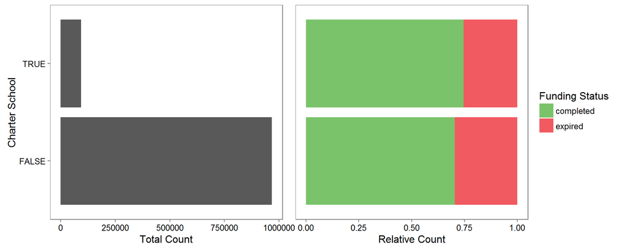

```r
Palette1 <- c("#7AC36A", "#F15A60")
draw_graphs <- function(df,prop1,prop2,name1,name2) {
  plot1 <- ggplot(df, aes(x = prop1)) + geom_bar() + coord_flip() + theme_few() + scale_y_continuous(name = "Total Count") + scale_x_discrete(name = name1)

  plot2 <- ggplot(df, aes(x = prop1, fill = prop2)) + geom_bar(position = "fill") + coord_flip() + theme_few() + theme(axis.title.y = element_blank(), axis.text.y = element_blank(), axis.ticks.y = element_blank()) + scale_fill_manual(name = name2, values=Palette1) + scale_y_continuous(name = "Relative Count")

  grid.draw(cbind(ggplotGrob(plot1), ggplotGrob(plot2), size = "last"))
}

draw_graphs(project, project$school_charter, project$funding_status, "Charter School", "Funding Status")
```

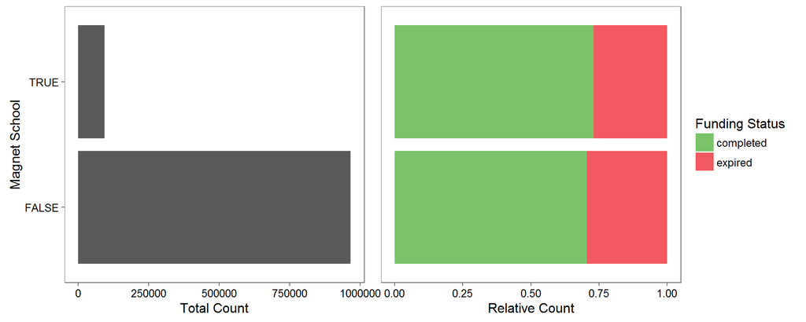

```r
draw_graphs(project, project$school_magnet, project$funding_status, "Magnet School", "Funding Status")
```

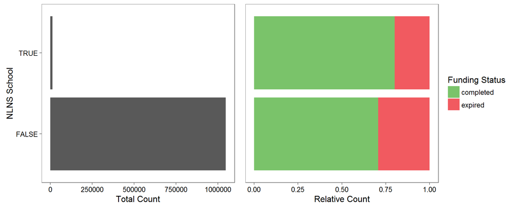

```r
draw_graphs(project, project$school_nlns, project$funding_status, "NLNS School", "Funding Status")
```

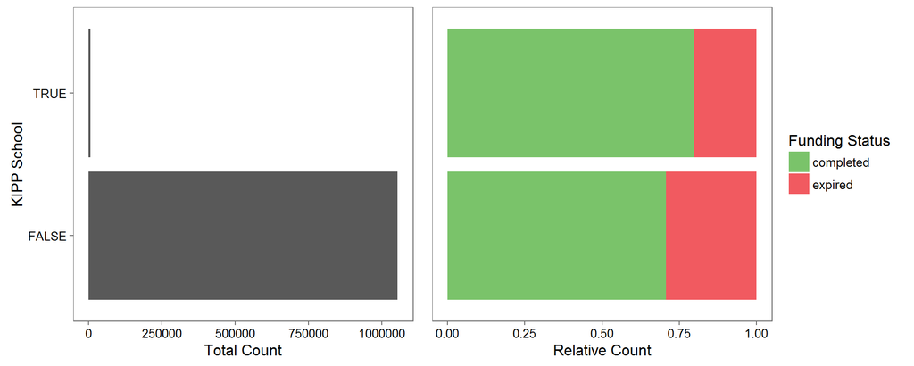

```r
draw_graphs(project, project$school_kipp, project$funding_status, "KIPP School", "Funding Status")
```

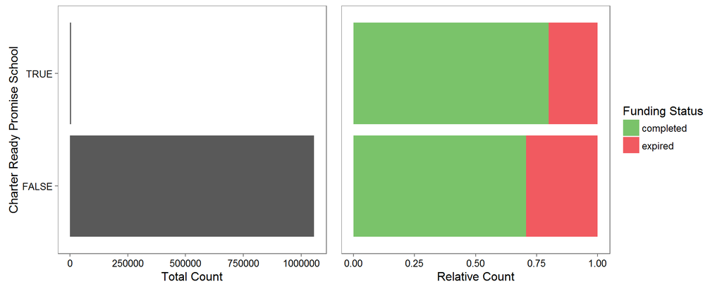

```r
draw_graphs(project, project$school_charter_ready_promise, project$funding_status, "Charter Ready Promise School", "Funding Status")
```

#### Teacher Attributes

The attributes of the teacher include:

- teacher_prefix
- teacher_teach_for_america
- teacher_ny_teaching_fellow

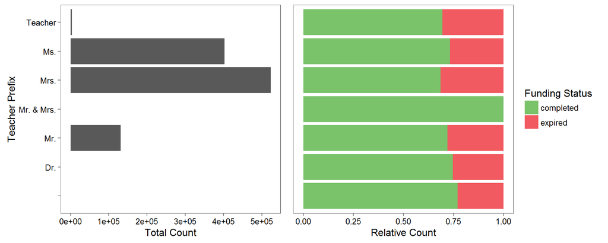

```r
draw_graphs(project, project$teacher_prefix, project$funding_status, "Teacher Prefix", "Funding Status")
```

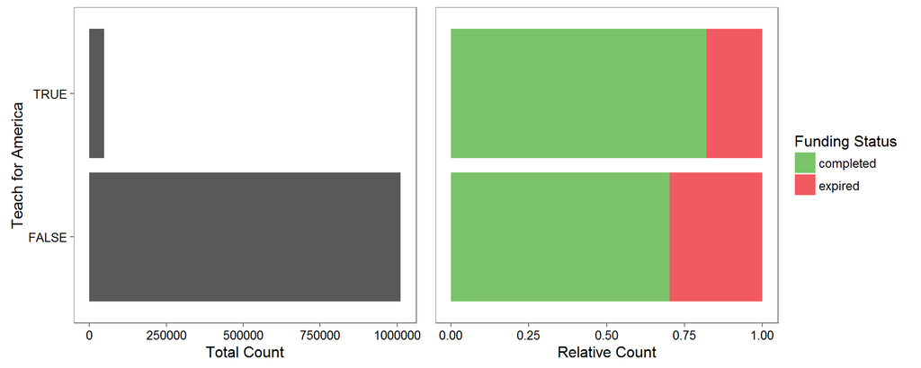

```r
draw_graphs(project, project$teacher_teach_for_america, project$funding_status, "Teach for America", "Funding Status")
```

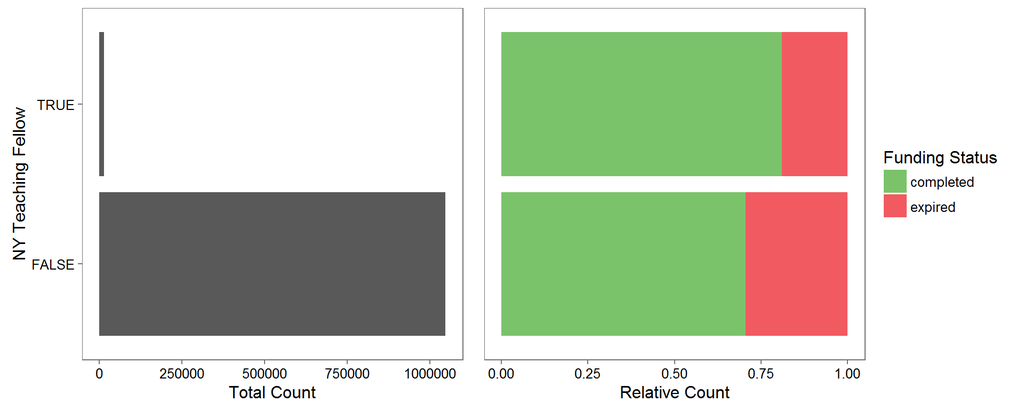

```r
draw_graphs(project, project$teacher_ny_teaching_fellow, project$funding_status, "NY Teaching Fellow", "Funding Status")
```

#### Project Categories

The project categories include:

- primary_focus_subject
- primary_focus_area
- secondary_focus_subject
- secondary_focus_area
- resource_type
- poverty_level
- grade_level

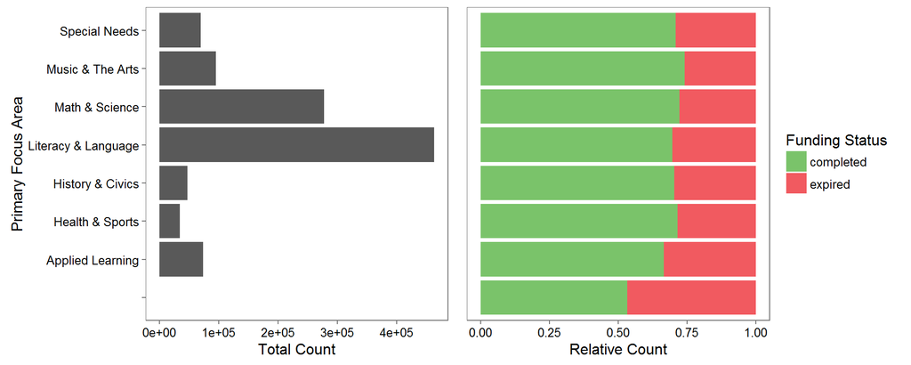

```r
draw_graphs(project, project$primary_focus_area, project$funding_status, "Primary Focus Area", "Funding Status")
```

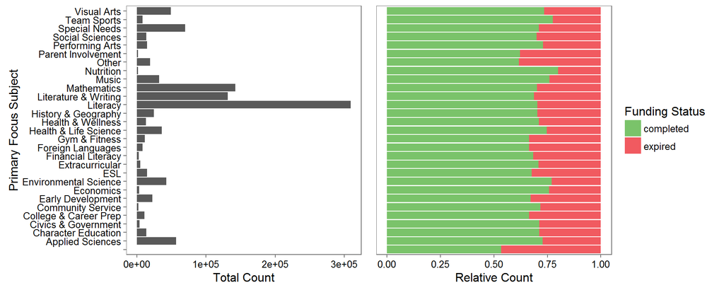

```r
draw_graphs(project, project$primary_focus_subject, project$funding_status, "Primary Focus Subject", "Funding Status")
```

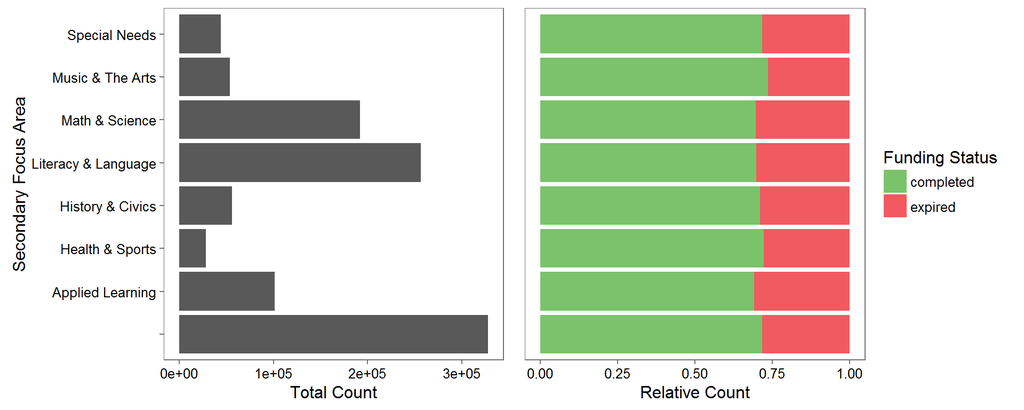

```r
draw_graphs(project, project$secondary_focus_area, project$funding_status, "Secondary Focus Area", "Funding Status")
```

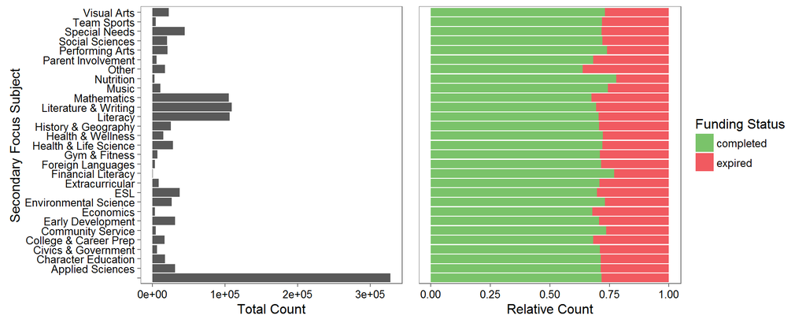

```r
draw_graphs(project, project$secondary_focus_subject, project$funding_status, "Secondary Focus Subject", "Funding Status")
```

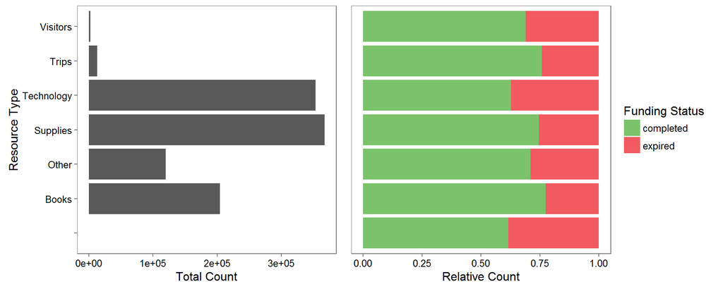

```r
draw_graphs(project, project$resource_type, project$funding_status, "Resource Type", "Funding Status")
```

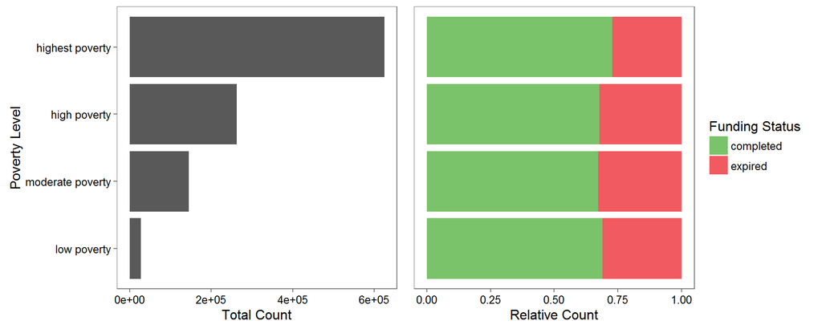

```r
draw_graphs(project, project$poverty_level, project$funding_status, "Poverty Level", "Funding Status")
```

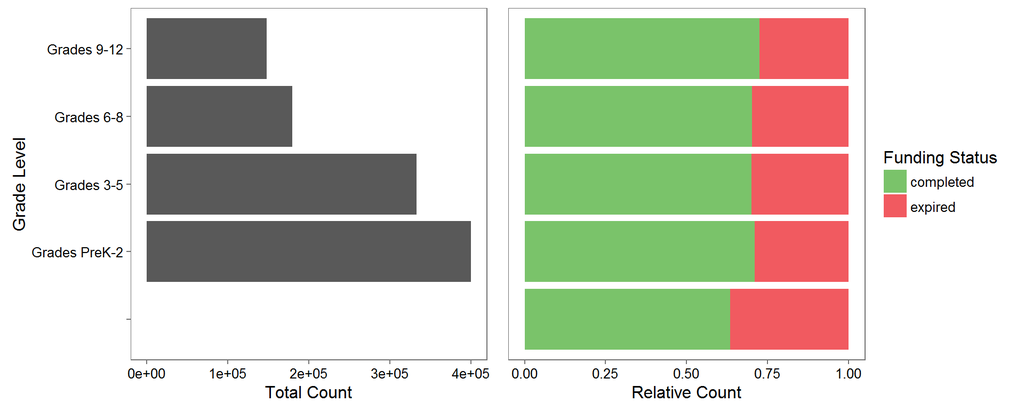

```r
draw_graphs(project, project$grade_level, project$funding_status, "Grade Level", "Funding Status")
```

#### Project Pricing and Impact

These fields are available under Project Details on a project page, breaking down the cost of a project into its parts.

- vendor_shipping_charges
- sales_tax
- payment_processing_charges
- fulfillment_labor_materials
- total_price_excluding_opt_donation
- total_price_including_opt_donation
- students_reached

Let’s look at some of these properties in more detail:

```r
summary(project$total_price_excluding_optional_support)
```

```
##     Min.  1st Qu.   Median     Mean  3rd Qu.     Max.
##        0      277      425      602      657 10250000
```

```r
summary(project$total_price_including_optional_support)
```

```
##     Min.  1st Qu.   Median     Mean  3rd Qu.     Max.
##        0      328      503      713      777 12500000
```

```r
summary(project$students_reached)
```

```
##     Min.  1st Qu.   Median     Mean  3rd Qu.     Max.     NA's
## 0.00e+00 2.20e+01 3.00e+01 9.56e+01 9.60e+01 1.00e+06      155
```

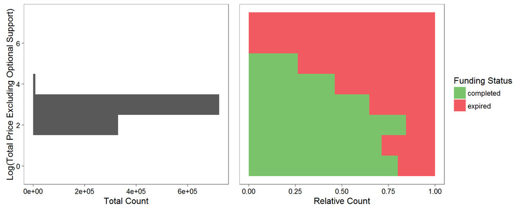

```r
draw_histograms <- function(df,prop1,prop2,name1,name2) {
  plot1 <- ggplot(df, aes(x = prop1)) + geom_histogram(binwidth = 1) + coord_flip() + theme_few() + scale_y_continuous(name = "Total Count") + scale_x_continuous(name = name1)

  plot2 <- ggplot(df, aes(x = prop1, fill = prop2)) + geom_histogram(binwidth = 1, position = "fill") + coord_flip() + theme_few() + theme(axis.title.y = element_blank(), axis.text.y = element_blank(), axis.ticks.y = element_blank()) + scale_fill_manual(name = name2, values=Palette1) + scale_y_continuous(name = "Relative Count")

  grid.draw(cbind(ggplotGrob(plot1), ggplotGrob(plot2), size = "last"))
}

draw_histograms(project, log10(project$total_price_excluding_optional_support), project$funding_status, "Log(Total Price Excluding Optional Support)", "Funding Status")
```

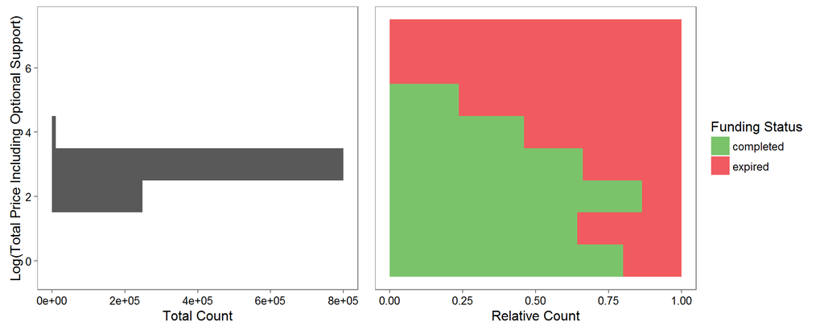

```r
draw_histograms(project, log10(project$total_price_including_optional_support), project$funding_status, "Log(Total Price Including Optional Support)", "Funding Status")
```

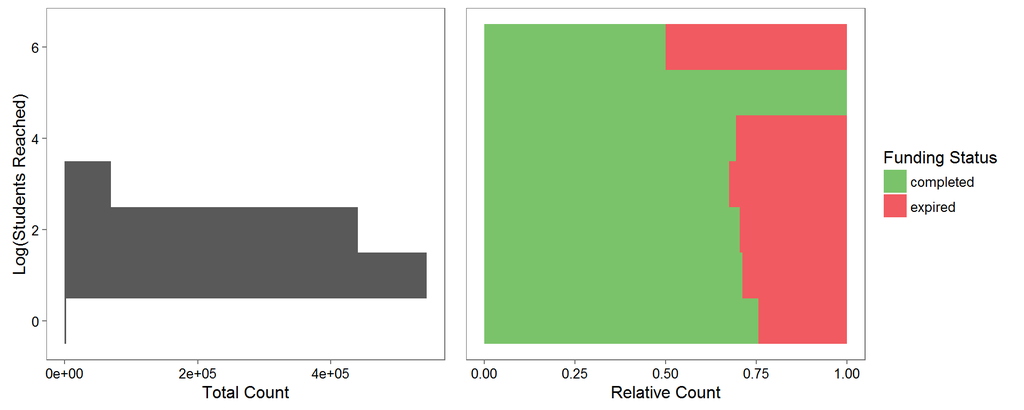

```r
draw_histograms(project, log10(project$students_reached), project$funding_status, "Log(Students Reached)", "Funding Status")
```

To Do: Take a closer look at some of the projects with Total Price = 0. Why is there no cost associated with these projects? Should these projects be removed from the dataset?

#### Project Donations

These fields provide information about the donations made to a particular project.

- total_donations: Total donation amount
- num_donors: Number of unique donors giving to this project
- eligible_double_your_impact_match: True if the project was ever eligible for a Double Your Impact match offer
- eligible_almost_home_match: True if the project was ever eligible for an Almost Home match offer

```r
summary(project$total_donations)
```

```
##     Min.  1st Qu.   Median     Mean  3rd Qu.     Max.
##      0.0    115.0    324.0    435.4    546.0 249300.0
```

```r
summary(project$num_donors)
```

```
##    Min. 1st Qu.  Median    Mean 3rd Qu.    Max.
##   0.000   1.000   3.000   4.413   6.000 848.000
```

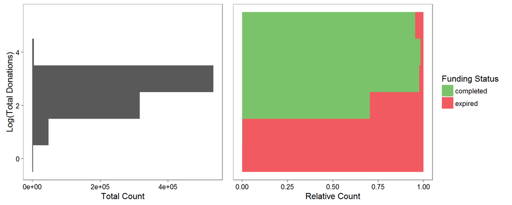

```r
draw_histograms(project, log10(project$total_donations), project$funding_status, "Log(Total Donations)", "Funding Status")
```

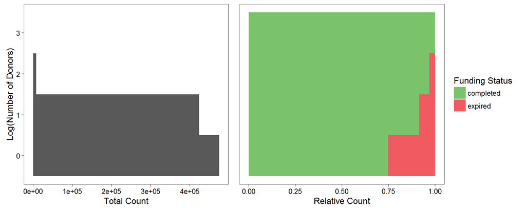

```r
draw_histograms(project, log10(project$num_donors), project$funding_status, "Log(Number of Donors)", "Funding Status")
```

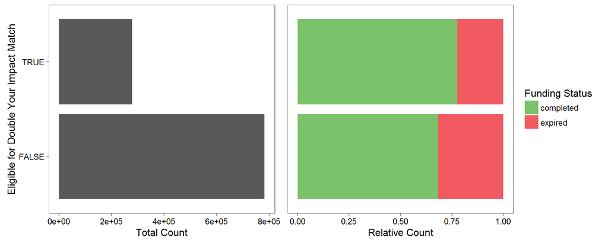

```r
draw_graphs(project, project$eligible_double_your_impact_match, project$funding_status, "Eligible for Double Your Impact Match", "Funding Status")
```

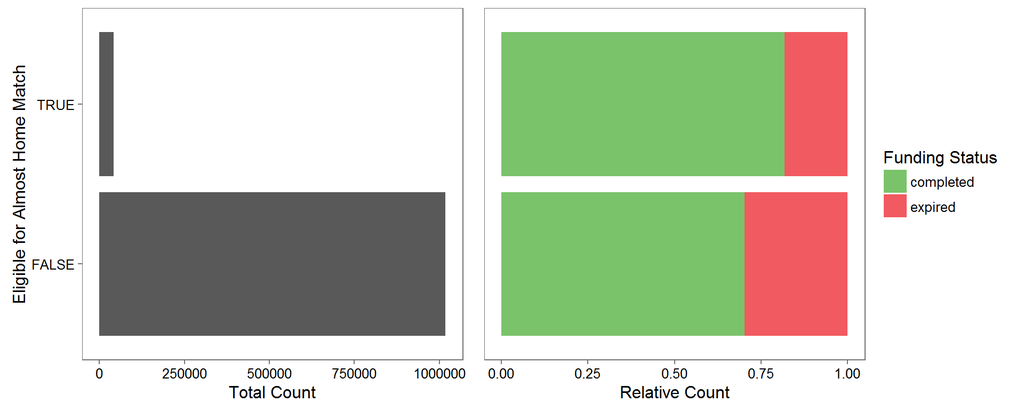

```r
draw_graphs(project, project$eligible_almost_home_match, project$funding_status, "Eligible for Almost Home Match", "Funding Status")
```

#### Project Status

These fields provide status information and dates for when a project reached their milestones.

- funding_status: Completed, Expired, Live, or Reallocated
- date_posted: Date a project was approved by staff to be listed on the site
- date_completed: Date a project become fully funded
- date_thank_you_packet_mailed: Date that the project went through the final stage of sending out a thank you package to donors
- date_expiration: Date the project was set to expire and be delisted from the site

We have already looked at funding_status. Let’s also look at the year the project was posted.

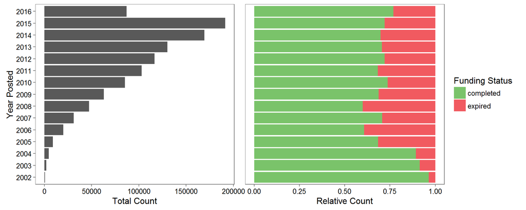

```r
draw_graphs(project, as.factor(format(project$date_posted, '%Y')), project$funding_status, "Year Posted", "Funding Status")
```

#### School Location

The fields describing school location include:

- school_latitude
- school_longitude
- school_city
- school_state
- school_zip: 5 Digit Zip
- school_metro: Urban, Suburban, or Rural
- school_district
- school_county

Let’s look at how school metro relates to funding status:

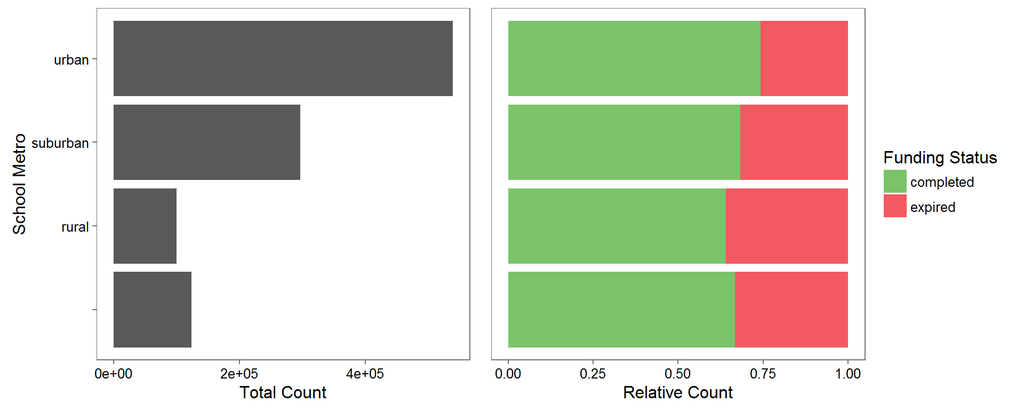

```r
draw_graphs(project, project$school_metro, project$funding_status, "School Metro", "Funding Status")
```

Let’s look at percentage of projects completed by state and by county:

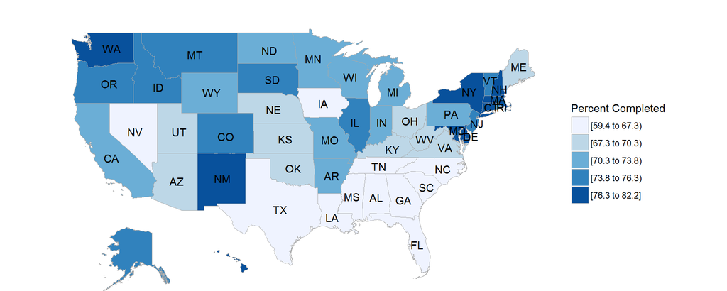

```r
project <- project %>% mutate(project_completed = as.integer(funding_status == "completed"))

state_summary <- project %>% group_by(school_state) %>% summarise(value = mean(project_completed) * 100) %>% rename(abb = school_state)

data(state.regions)
state_summary <- left_join(state_summary, state.regions, by="abb")

state_choropleth(state_summary, num_colors = 5, legend = "Percent Completed")
```

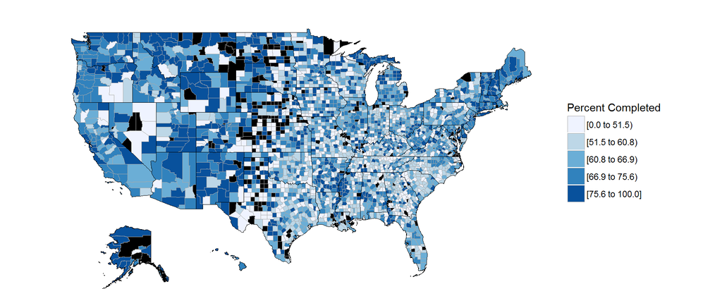

```r
county_summary <- project %>% rename(state.abb = school_state, county.name = school_county) %>% mutate(county.name = tolower(county.name)) %>% group_by(county.name, state.abb) %>% summarise(value = mean(project_completed) * 100)

data("county.regions")
county_summary <- left_join(county.regions, county_summary, by=c("state.abb","county.name"))

county_choropleth(county_summary, num_colors = 5, legend = "Percent Completed")
```

#### Additional Properties of Interest

##### New Teacher, New School

The DonorsChoose.org website allows donors to search for projects according to a number of different criteria including “Never before funded teachers” and “Never before funded schools”. These properties are not tracked in the original dataset, so let’s figure that out now.

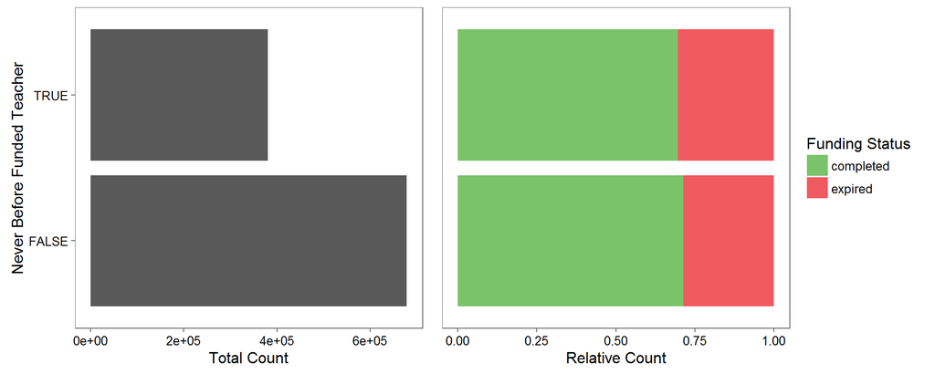

```r
project <- project %>% arrange(date_posted)
project$teacher_new <- !duplicated(project$X_teacher_acctid)
project$school_new <- !duplicated(project$X_schoolid)

draw_graphs(project, project$teacher_new, project$funding_status, "Never Before Funded Teacher", "Funding Status")
```

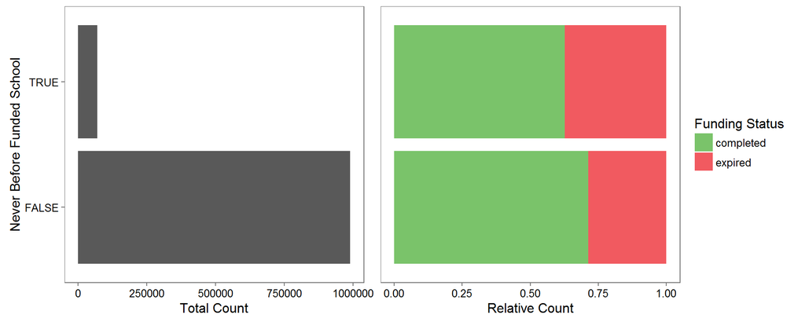

```r
draw_graphs(project, project$school_new, project$funding_status, "Never Before Funded School", "Funding Status")
```

## Essay Data

Next, let’s examine the project essay data. This includes the full text of the teacher-written requests accompanying all classroom projects.

#### Importing the file

```r
essay_orig <- fread("opendata_essays0002/opendata_essays000.csv", sep = ",", header = FALSE, data.table = FALSE, nrows = 10000, col.names = c('_projectid', '_teacher_acctid', 'title', 'short_description', 'need_statement', 'essay', 'thankyou_note', 'impact_letter'))
```

#### Sentiment Analysis using AFINN Lexicon

Let’s perform sentiment analysis on each essay using the AFINN lexicon, which provides a positivity score for each word, from -5 (most negative) to 5 (most positive). Then we can average the sentiment score for each essay and plot the results.

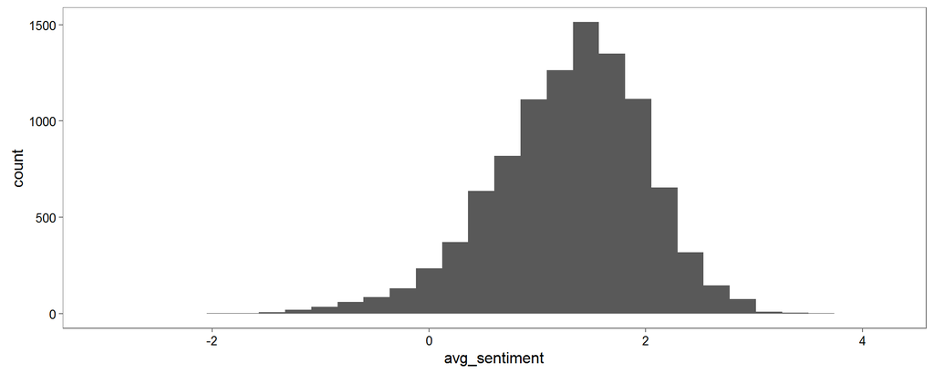

```r
essay_words <- essay_orig %>%
  select(`_projectid`, `_teacher_acctid`, essay) %>%
  unnest_tokens(word, essay) %>%
  filter(!word %in% stop_words$word,
         str_detect(word, "^[a-z']+$"))

AFINN <- subset(sentiments, lexicon == "AFINN", select = c(word, score))

afinn_sentiment <- essay_words %>%
  inner_join(AFINN, by = "word") %>%
  group_by(`_projectid`, `_teacher_acctid`) %>%
  summarize(avg_sentiment = mean(score))

ggplot(afinn_sentiment, aes(x=avg_sentiment)) + geom_histogram() + theme_few()
```

#### Sentiment Analysis using Bing Lexicon

Let’s perform sentiment analysis on each essay using the Bing lexicon, which rates words as positive or negative. Then we can calculate the difference between the number of positive and negative words in each essay and plot the results.

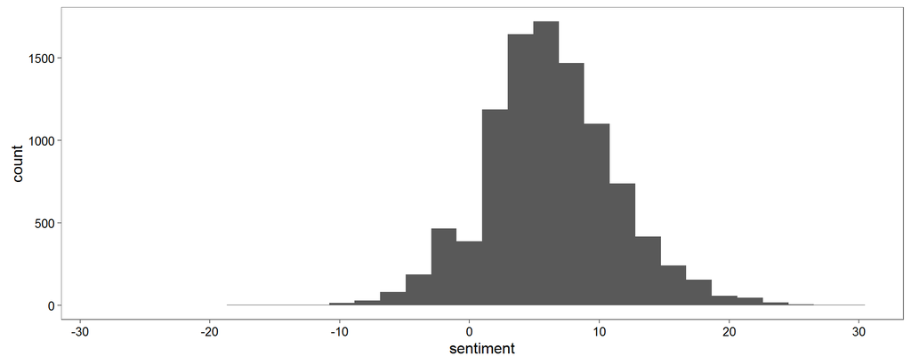

```r
bing <- get_sentiments("bing")

bing_sentiment <- essay_words %>%
  inner_join(bing) %>%
  count(`_projectid`, `_teacher_acctid`, sentiment) %>%
  spread(sentiment, n, fill = 0) %>%
  mutate(sentiment = positive - negative)

ggplot(bing_sentiment, aes(x=sentiment)) + geom_histogram() + theme_few()
```